# Motorcycle accident: solution

Matteo Fasiolo, Simon N. Wood

2019-09-20

1. Load data and look at it

```r
library(MASS)
library(mgcv)
data("mcycle")

head(mcycle, 10)
```

```
##    times accel
## 1    2.4   0.0
## 2    2.6  -1.3
## 3    3.2  -2.7
## 4    3.6   0.0
## 5    4.0  -2.7
## 6    6.2  -2.7
## 7    6.6  -2.7
## 8    6.8  -1.3
## 9    7.8  -2.7
## 10   8.2  -2.7
```

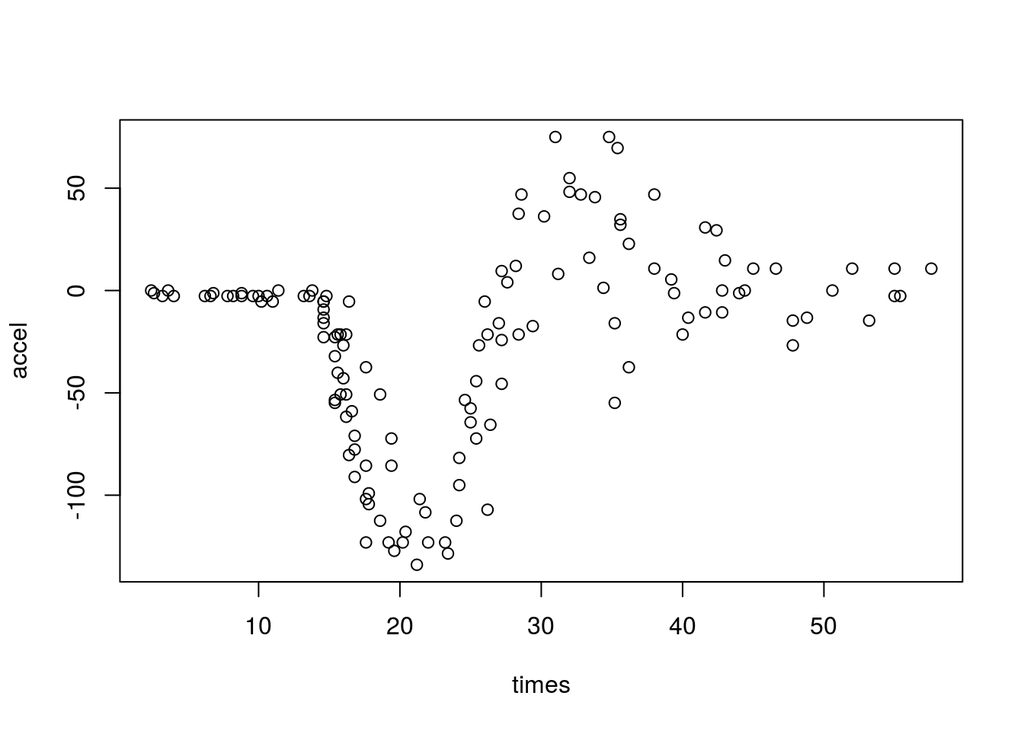

```r
plot(mcycle)
```

Nothing happens until around 15 milliseconds after the impact.

2. We start with a simple Gaussian model

```r
fitG <- gam(accel ~ s(times), data = mcycle)
```

We now plot the fitted mean, with credible intervals, against the data

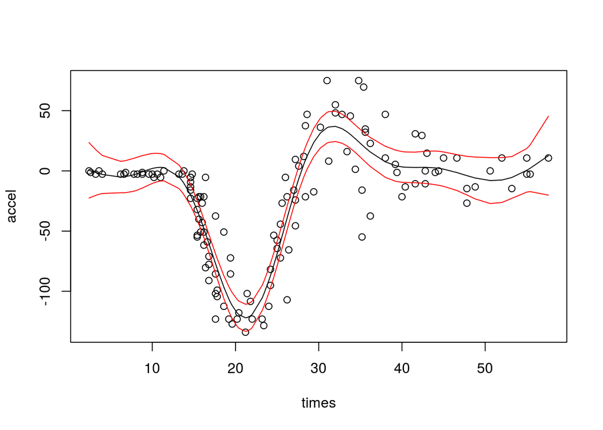

```r
plot(mcycle)
pr <- predict(fitG, se = TRUE)
lines(mcycle$times, pr$fit)
lines(mcycle$times, pr$fit + 2*pr$se, col = 2)
lines(mcycle$times, pr$fit - 2*pr$se, col = 2)
```

There are several problems with this fit, in particular a) the fit is wiggly where it should be quite flat (`times < 15` and `times > 35`) and b) the intervals have similar width for `times < 15` and for `times > 30` which is clearly inappropriate given that the variance of the residuals increases from left to right. In the following we try to address these issues.

3. Let’s look at some diagnostics

```r
par(mfrow = c(2, 2))
gam.check(fitG)
```

```
##
## Method: GCV   Optimizer: magic
## Smoothing parameter selection converged after 8 iterations.
## The RMS GCV score gradient at convergence was 0.0009645413 .
## The Hessian was positive definite.
## Model rank =  10 / 10
##
## Basis dimension (k) checking results. Low p-value (k-index<1) may
## indicate that k is too low, especially if edf is close to k'.
##
##            k'  edf k-index p-value
## s(times) 9.00 8.69    1.15    0.96
```

We start by considering the text output (the plots produced by `check.gam` have been hidden in this file). We see that `edf` is quite close to `k'`, which suggests that we should increase the number of basis function used. Hence we refit with `k = 20` and re-check

```r
fitG2 <- gam(accel ~ s(times, k = 20), data = mcycle)
gam.check(fitG2)
```

```
##
## Method: GCV   Optimizer: magic
## Smoothing parameter selection converged after 6 iterations.
## The RMS GCV score gradient at convergence was 0.001283199 .
## The Hessian was positive definite.
## Model rank =  20 / 20
##
## Basis dimension (k) checking results. Low p-value (k-index<1) may
## indicate that k is too low, especially if edf is close to k'.
##
##            k'  edf k-index p-value
## s(times) 19.0 10.9    1.15    0.96
```

Now `edf` is well below `k'`, and increasing `k` further seems unnecessary.

4. We try using an adaptive basis

```r
fitG2_ad <- gam(accel ~ s(times, k = 20, bs = 'ad'), data = mcycle)
gam.check(fitG2_ad)
```

```
##
## Method: GCV   Optimizer: magic
## Smoothing parameter selection converged after 23 iterations.
## The RMS GCV score gradient at convergence was 0.0005575868 .
## The Hessian was positive definite.
## Model rank =  20 / 20
##
## Basis dimension (k) checking results. Low p-value (k-index<1) may
## indicate that k is too low, especially if edf is close to k'.
##
##             k'   edf k-index p-value
## s(times) 19.00  7.87    1.14    0.94
```

Notice that `edf` has gone down, relative to the non-adaptive basis. This is because the adaptive basis is able to concentrate all the wiggliness where it is needed (time between 15 and 30 milliseconds), and it produces a nearly linear fit elsewhere. This can be seen by comparing the fitted effects

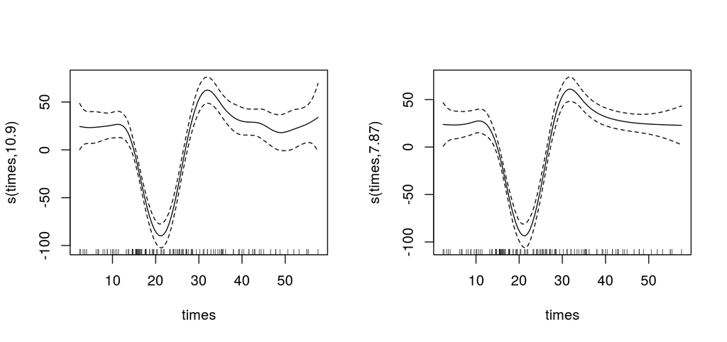

```r
par(mfrow = c(1, 2))
plot(fitG2)
plot(fitG2_ad)
```

Using an adaptive smooth helped us removing some spurious wiggliness for `times > 35` (this was the first issue we mentioned above).

5. Now we start looking at the model residuals

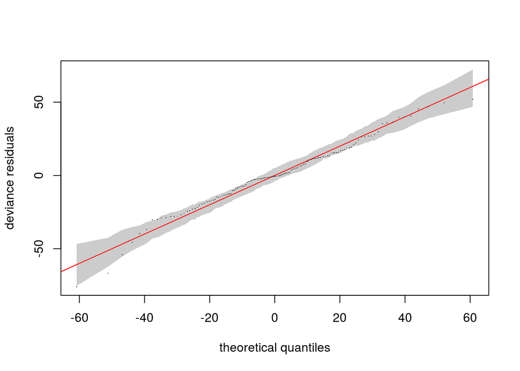

```r
qq.gam(fitG2_ad, rep = 100)
```

The QQ-plot does not look to bad. However, as we have said before, the data is clearly heteroscedastic. We can see this by looking at the log square residuals

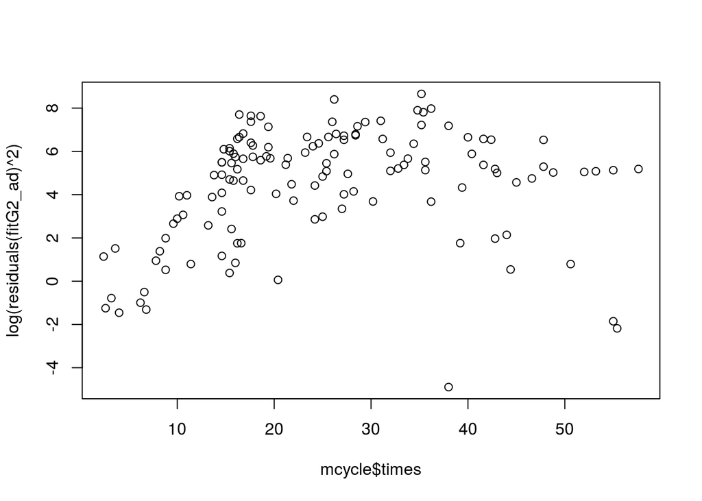

```r
plot(mcycle$times, log(residuals(fitG2_ad)^2))
```

The variance of the residuals is clearly not constant.

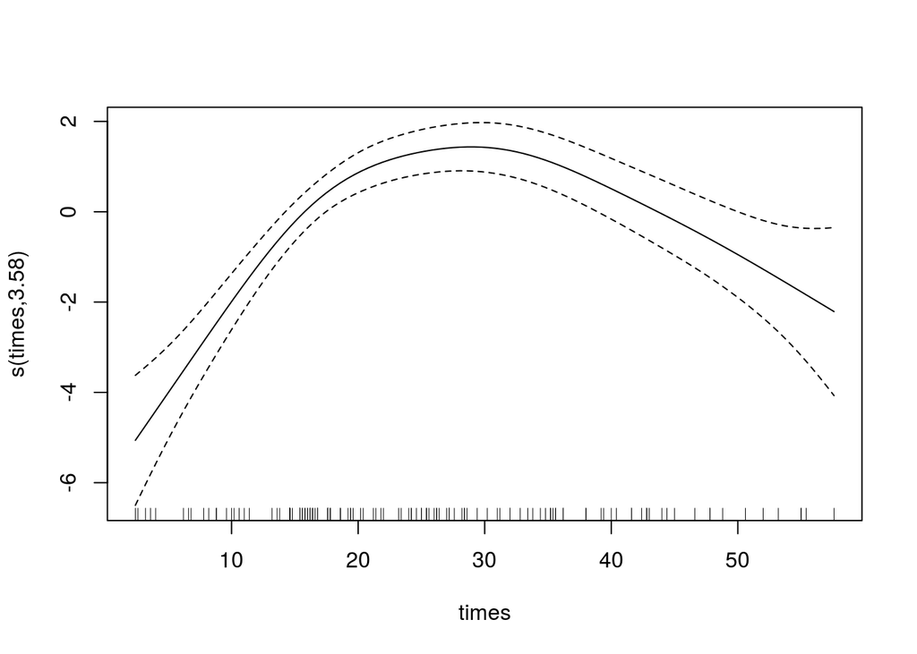

```r
mcycle$res2 <- log( residuals(fitG2_ad, type = "response")^2 )
fitRes <- gam(res2 ~ s(times), data = mcycle)
plot(fitRes)
```

```r
w <- 1 / exp(fitRes$fitted.values) # 1 / variance
fitG2_ad_w <- gam(accel ~ s(times, k = 20, bs = 'ad'),
                  weights = w,
                  data = mcycle)
```

The confidence bands width now nicely changes with times, as can be seen in the following plots

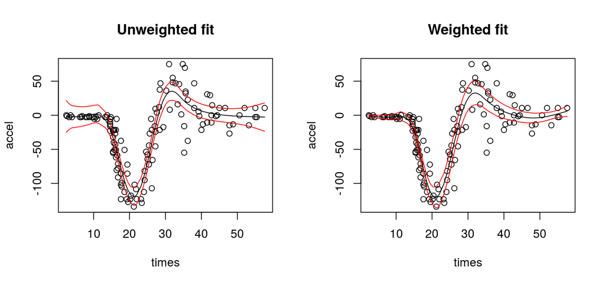

```r
par(mfrow = c(1, 2))
plot(mcycle[ , c("times", "accel")], main = "Unweighted fit")
pr <- predict(fitG2_ad, se = TRUE)
lines(mcycle$times, pr$fit)
lines(mcycle$times, pr$fit + 2*pr$se, col = 2)
lines(mcycle$times, pr$fit - 2*pr$se, col = 2)

plot(mcycle[ , c("times", "accel")], main = "Weighted fit")
pr <- predict(fitG2_ad_w, se = TRUE)
lines(mcycle$times, pr$fit)
lines(mcycle$times, pr$fit + 2*pr$se, col = 2)
lines(mcycle$times, pr$fit - 2*pr$se, col = 2)
```

7. We model mean and variance jointly using a Gaussian location scale model

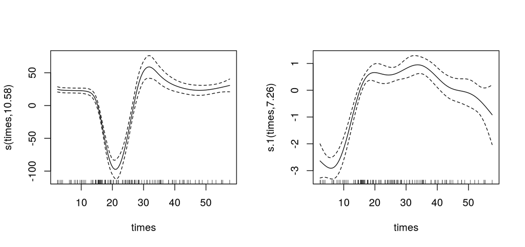

```r
fit_ls <- gam(list(accel ~ s(times, k=20, bs="ad"), ~s(times)),
              data=mcycle,
              family=gaulss())

plot(fit_ls, pages=1, scale=0)
```

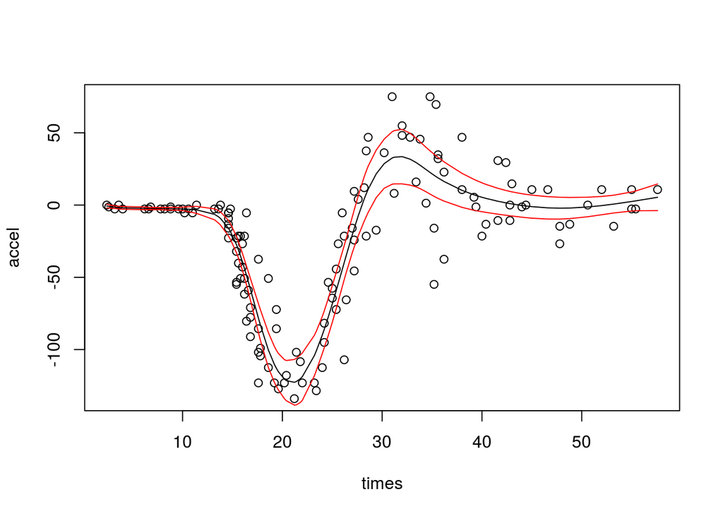

```r
plot(mcycle[ , c("times", "accel")])
pr <- predict(fit_ls, se = TRUE)
lines(mcycle$times, pr$fit[ , 1])
lines(mcycle$times, pr$fit[ , 1] + 2*pr$se[ , 1], col = 2)
lines(mcycle$times, pr$fit[ , 1] - 2*pr$se[ , 1], col = 2)
```